# Geospatial Data Mining: Criminal Site Selection (CSS) Models

Friday, May 20, 2016

## CSS Modeling Background: Criminal Preference

- **Criminal Preference:** According to *crime pattern theory* and *rational choice theory*, criminals have definite preferences about the features of the locations where they commit crimes.
  - **Spatial:**
    - Travel distance from hide to crime
    - Distance from reacting forces (police stations, TCPs)
    - Distance to key spatial features (streets, banks, bar)
  - **Demographic/Economic (Cultural):**
    - Burglaries in high end neighborhoods
    - Sunni vs. Shia violence in Baghdad
    - Tribal/Gang affiliation
- **Situational Crime Prevention:** identifies why crime occurs in specific settings and seeks solutions that reflect the nature of those settings.

## CSS Modeling Background: Spatial Choice

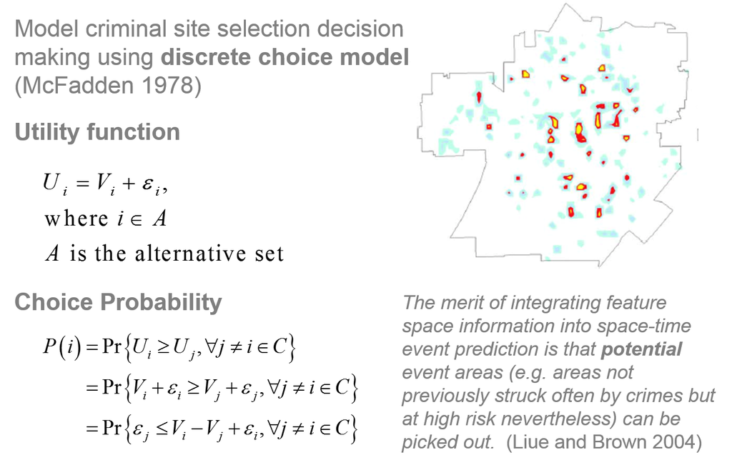

## CSS Modeling Process

1. Import and Organize Shapefiles (Munge)
2. Develop CSS Modeling Data Frames (Munge)
3. Develop CSS Models (Model)
4. Evaluate CSS Model Performance (Model)
5. Develop Maps of CSS Model Prediction (Visualize)

## Example Application: Criminal Gangs (Santa Ana)

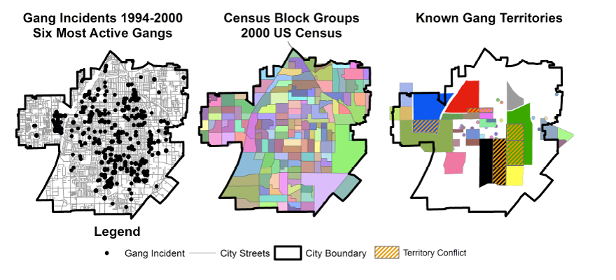

**Can we use spatial information about previous crimes to predict where criminal gangs will commit crimes in the future (applicable to targeting, resource allocation, etc.)?**

## Import and Organize Shapefiles (2 of 7)

```r
SA.Outline<-readOGR(getwd(),"SA_Outline")
Gang.Territory<-readOGR(getwd(),"GangTerritory")
Incidents<-readOGR(getwd(),"GangIncidents")
plot(SA.Outline)
plot(Gang.Territory, add=TRUE, col="blue")
plot(Incidents, add=TRUE, col="red", pch=20)
```

**There is something missing below…why?**

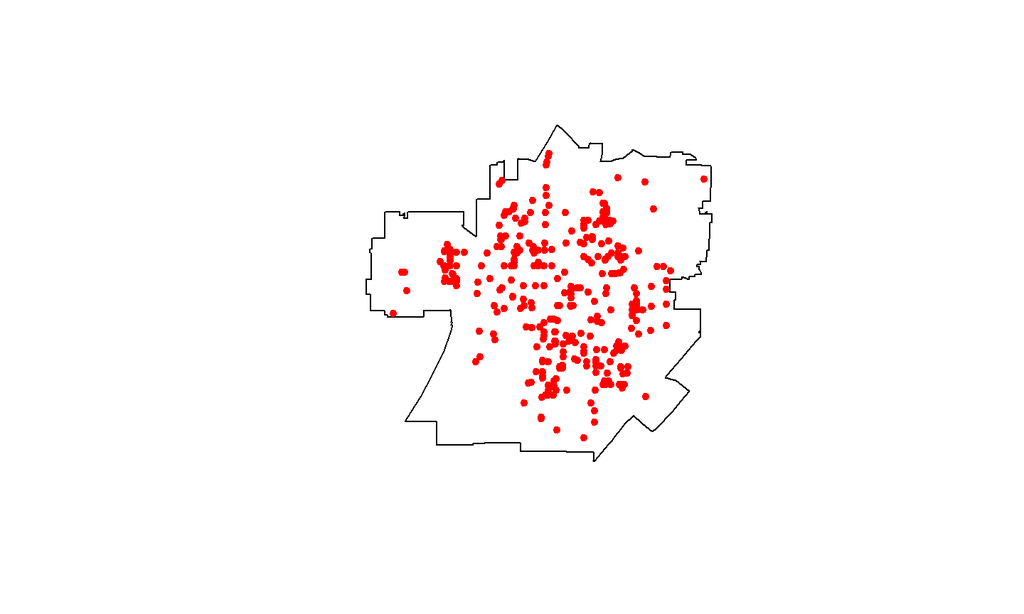

## Geographic Coordinate Systems Primer

- **The following are two common types of coordinate systems used in a geographic information system (GIS):**
  - A **global or spherical coordinate system** such as latitude-longitude. These are often referred to as geographic coordinate systems.
  - A **projected coordinate system** such as universal transverse Mercator (UTM), Albers Equal Area, or Robinson, all of which (along with numerous other map projection models) provide various mechanisms to project maps of the earth's spherical surface onto a two-dimensional Cartesian coordinate plane. Projected coordinate systems are referred to as map projections.
- **Coordinate systems (both geographic and projected) provide a framework for defining real-world locations.**
- **If your shapefiles are not in the same coordinate system/projection, they will not line up.**

Definitions Source: resources.esri.com

## Import and Organize Shapefiles (4 of 7)

**To *read* the coordinate system in a shapefile:**

```r
proj4string(SA.Outline)
```

```
## [1] "+proj=lcc +lat_1=32.78333333333333 +lat_2=33.88333333333333 +lat_0=32.16666666666666 +lon_0=-116.25 +x_0=2000000 +y_0=500000.0000000002 +datum=NAD83 +units=us-ft +no_defs +ellps=GRS80 +towgs84=0,0,0"
```

```r
proj4string(Gang.Territory)
```

```
## [1] "+proj=longlat +datum=NAD83 +no_defs +ellps=GRS80 +towgs84=0,0,0"
```

**To *transform* a shapefile to a new coordinate system:**

```r
Gang.Territory<-spTransform(Gang.Territory, CRS(proj4string(SA.Outline)))
```

## Now (spTransform all layers)…

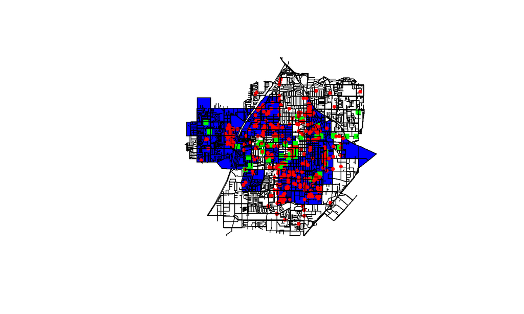

```r
#Plot to check
plot(SA.Outline)
plot(Gang.Territory, add=TRUE, col="blue")
plot(Streets, add=TRUE)
plot(Gang.Points, add=TRUE, col="green", pch=15)
plot(Incidents, add=TRUE, col="red", pch=20)
plot(Block.Groups, add=TRUE)
```

## Import and Organize Shapefiles (6 of 7)

**To view the dataframe of a shapefile, use the @ operator:**

```r
summary(Incidents@data)
```

```
##       X_1            X           OBJECTID         CASENO
##  Min.   :  1   Min.   :  17   Min.   :  27   00-04164:  1
##  1st Qu.:102   1st Qu.:1264   1st Qu.:1023   00-04717:  1
##  Median :203   Median :2680   Median :2486   00-04810:  1
##  Mean   :203   Mean   :2682   Mean   :2783   00-05321:  1
##  3rd Qu.:304   3rd Qu.:3950   3rd Qu.:4457   00-06487:  1
##  Max.   :405   Max.   :5464   Max.   :6238   00-07693:  1
##                                              (Other) :399
##     CASEDATE              HOUR_                CITY        CRIMTYPE
##  Min.   :1994-01-03   Min.   :   5   GARDEN GROVE:  1   Min.   : 2.00
##  1st Qu.:1995-07-01   1st Qu.:1210   SANTA ANA   :404   1st Qu.: 7.00
##  Median :1997-01-29   Median :1655                      Median :14.00
##  Mean   :1997-04-12   Mean   :1524                      Mean   :13.15
##  3rd Qu.:1999-02-04   3rd Qu.:2059                      3rd Qu.:20.00
##  Max.   :2000-12-31   Max.   :2348                      Max.   :21.00
##
##      CRIME1          YEAR_        GangName     Gang_ID
##  Min.   :1.000   Min.   :   0   Gang 1:80   Min.   :1.000
##  1st Qu.:1.000   1st Qu.:1994   Gang 2:66   1st Qu.:2.000
##  Median :1.000   Median :1996   Gang 3:75   Median :3.000
##  Mean   :2.326   Mean   :1740   Gang 4:48   Mean   :3.365
##  3rd Qu.:4.000   3rd Qu.:1998   Gang 5:82   3rd Qu.:5.000
##  Max.   :5.000   Max.   :1999   Gang 6:54   Max.   :6.000
##
```

## Import and Organize Shapefiles (7 of 7)

**To access columns in the dataframe, use the @ and $ operators:**

```r
head(Incidents@data$CASEDATE)
```

```
## [1] "1995-05-23" "1997-06-16" "1999-01-25" "1999-04-22" "1999-09-17"
## [6] "1996-06-14"
```

```r
head(Incidents@data$GangName)
```

```
## [1] Gang 3 Gang 4 Gang 4 Gang 5 Gang 4 Gang 4
## Levels: Gang 1 Gang 2 Gang 3 Gang 4 Gang 5 Gang 6
```

## Develop CSS Modeling Data Frames

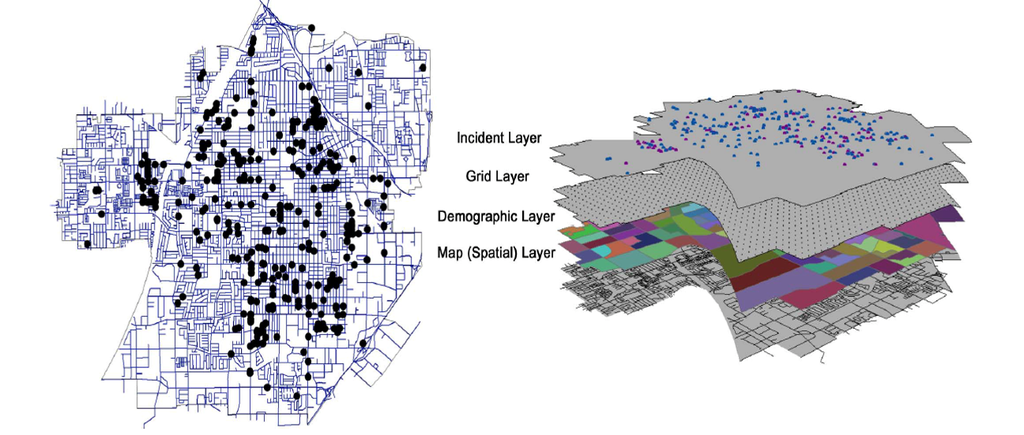

- **Dependent (Response) Variable:** incidents (Response = 1) vs. null grid (Response = 0).
- **Independent (Predictor) Variables:** incidents and null grid given feature space, categorical, and demographic attributes of their locations in geography.

## Feature Space Predictors (1 of 2)

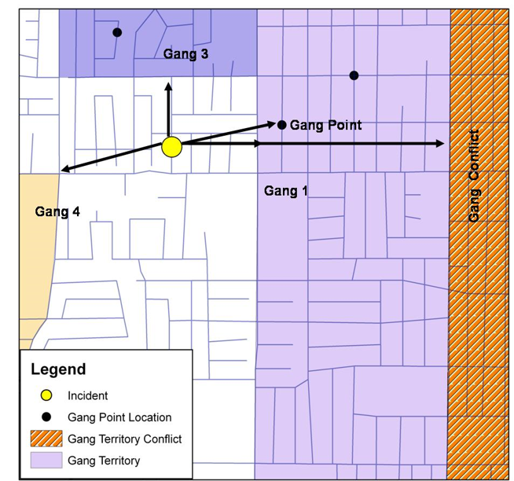

Feature space is a higher dimensional representation of the position of an incident. Rather than an incident being located by X and Y coordinate, it is located by the Euclidean distance to each of the features in the feature space dataset (gang territory, gang conflict, street, etc.)

## Feature Space Predictors (2 of 2)

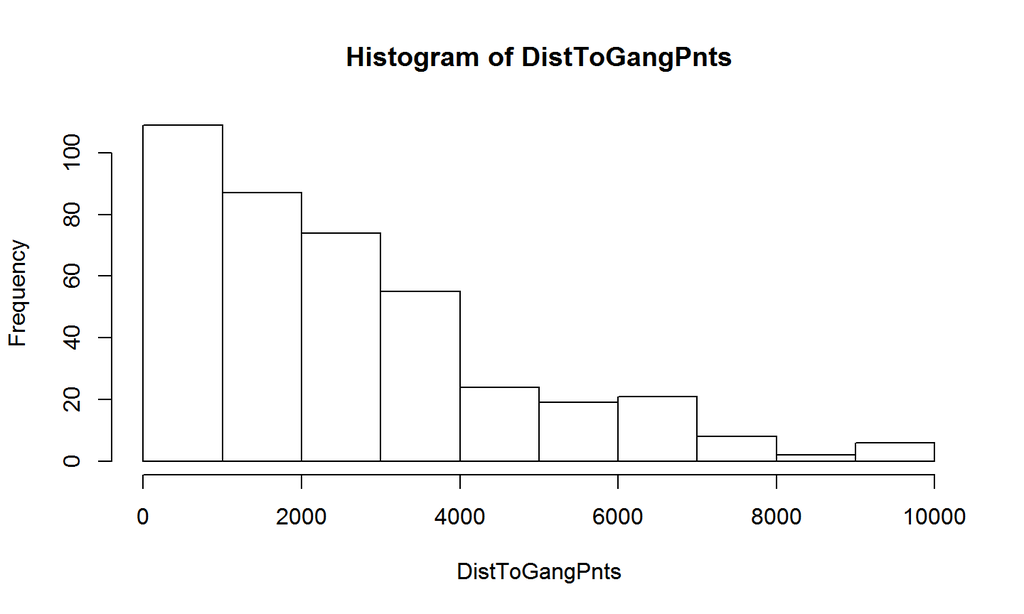

```r
Response<-data.frame(rep(1, length(Incidents@data[,1])))
colnames(Response)<-"Response"
Inc.Data<-Incidents
Inc.Data@data<-Response
DistToGangPnts<-nncross(as.ppp(Inc.Data), as.ppp(Gang.Points))[,1]
hist(DistToGangPnts)
```

## Categorical Predictors

```r
Territory.Check<-over(Inc.Data, Gang.Territory)[,1]
InGangTerr<-vector(mode="numeric", length=length(Territory.Check))
InGangTerr[!is.na(Territory.Check)]<-1
```

The code block uses the over() and the !is.na() functions to assign a categorical value of 1 to any location that falls within a gang territory and a categorical value of 0 (by default) to any location that does not.

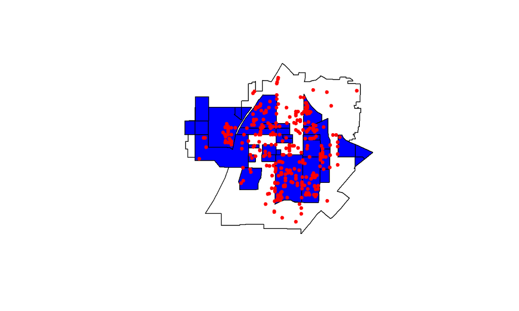

## Demographic Predictors

**We can also use the over() function to assign a point layer (either incidents or null grid) the demographic values of the census block group they fall within:**

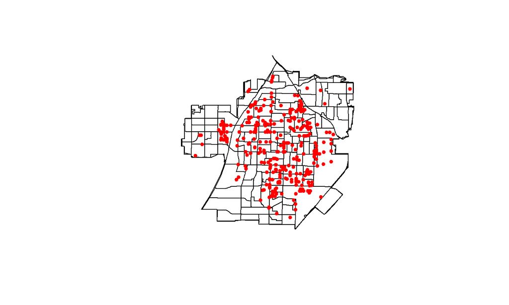

```r
Inc.Demographics<-over(Inc.Data, Block.Groups)
#Create Predictor Matrix for Incidents
Inc.Pred.Matrix<-cbind(Response, DistToGangPnts, DistToStreet, InGangTerr,
                       Inc.Demographics[,10:52])
Inc.Data@data<-Inc.Pred.Matrix
```

## Train vs. Test vs. Model vs. Predict Datasets

**For CSS Models, we generate four different kinds of datasets:**

## CSS Models

**Initial Model Fitting on Train Data:**

```r
# Logistic Regression on Feature-Space Predictors
Model.1<-glm(Response ~ DistToGangPnts + DistToStreet + InGangTerr, family="binomial", data=Train.Data)

# Stepwise Logistic Regression on Feature-Space Predictors
Model.2<-glm(Response ~., family="binomial", data=Train.Data)
Model.3<-step(Model.2)

# Random Forest Model
Model.4<-randomForest(as.factor(Response) ~., data=Train.Data)
```

**Prediction on Test Data:**

```r
# Logistic Regression Models use invlogit() and predict()
M1.prediction<-as.vector(invlogit(predict(Model.1, newdata=Test.Data)))
M3.prediction<-as.vector(invlogit(predict(Model.3, newdata=Test.Data)))

# Random Forest predicts probability for both "classes" - you must refine
M4.prediction<-predict(Model.4, newdata=Test.Data, type="prob")[,2]
```

## Surveillance Plot: Evaluating CSS Model Performance (Test Dataset)

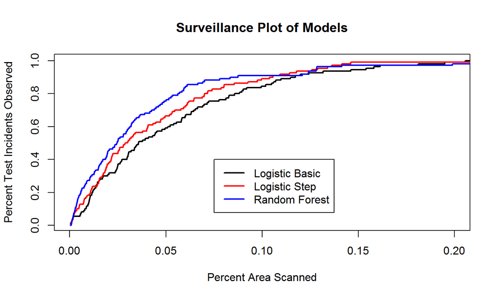

## Predict Using Best Modeling Approach and All Your Data

```r
######### Build model on ALL Observations
Model.Data<-rbind(Null.Train@data, Inc.Data@data)

# Build Final Model on Model.Data dataframe
Model.5<-randomForest(as.factor(Response) ~., data=Model.Data)

# First do the prediction on the grid points to confirm class
head(predict(Model.5, newdata=Null.Data, type="prob"))

# Predict on grid - note Class "1" is in column 2
Prediction<-predict(Model.5, newdata=Null.Data, type="prob")[,2]
Prediction[is.na(Prediction)]<-0  #Points outside of Santa Ana are NA

# Add prediction to Null.Data data frame (for visualization)
Null.Data@data<-cbind(Null.Data@data, Prediction)
```

## Generate a Raster Image of the Prediction

```r
library(raster)
r <- raster(ncol=200, nrow=200)
extent(r) <- extent(SA.Outline)
Prediction.Raster<- rasterize(Null.Data, r, 'Prediction')
```

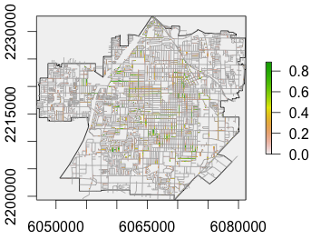

- **What could we do to make this map better?**

## Use Leaflet for Interactive Map

```r
library(leaflet)
library(RColorBrewer)
#Set the projection for our raster and street map
crs(Prediction.Raster) <- sp::CRS(proj4string(SA.Outline))
#Add color palette using RColorBrewer
palette<-brewer.pal(8, "Reds")
pal <- colorNumeric(palette, values(Prediction.Raster),
                    na.color = "transparent")
#Define Lat-Long for our plot using extent()
Latitude=mean(extent(Streets)[1:2])
Longitude=mean(extent(Streets)[3:4])

my.map<-leaflet() %>%
   setView(Latitude, Longitude, zoom = 12) %>%
   addProviderTiles("Stamen.Toner") %>%
   addRasterImage(Prediction.Raster, colors = pal, opacity = .8) %>%
   addLegend(pal = pal, values = values(Prediction.Raster),
         title = "Prediction")
my.map   #to plot the map
```

## Results: An Interactive Hot-Spot Map

[figure not shown]

## Summary

- **Munge**
  - readOGR() for shapefile importation
  - proj4string() for organizing your projections/coordinate systems
  - Use plotting to make sure your shapefiles line up
- **Model**
  - Train vs. Test vs. Model vs. Predict Datasets
  - Surveillance plot for model evaluation (on test data set)
  - Predict using **best modeling approach and all your data**
- **Visualize**
  - Basic plotting provides quick check
  - Provide interactivity and map orientation using leaflet()

## References

- Liu, H., Brown, D.E.: A new point process transition density model for space-time event prediction. IEEE Transactions on Systems, Man, and Cybernetics, Part C: Applications and Reviews 34, 310â324 (2004)
- Xue, Y., Brown, D.E.: Spatial analysis with preference specification of latent decision makers for criminal event prediction. Decision Support Systems 41(3) (2006)
- Brown, D.E., Dalton, J., Hoyle, H.: Spatial forecast methods for terrorist events in urban environments. In: Second Symposium on Intelligence and Security Informatics (June 2004)
- Smith, M.A., Brown, D.E.: Application of discrete choice analysis to attack point patterns. Information Systems and e-Business Management 5(3) (June 2007)
- Huddleston, S.H., Brown, D.E.: A statistical threat assessment." IEEE Transactions on Systems, Man, and Cybernetics - Part A: Systems and Humans 39(6) (2009)
- Huddleston, S.H., Fox, J., Brown, D.E.: Mapping gang spheres of influence. Crime Mapping: A Journal of Research and Practice 4(2) (2012)
- Huddleston, S.H., Gerber, M.S., Brown, D.E.: Geographic Profiling of Criminal Groups for Military Cordon and Search. Social Computing, Behavioral-Cultural Modeling and Prediction, 503-512 (2014)
- McFadden, D.: Modelling the choice of residential location. Anders Karlqvist (Ed.), et al., Spatial interaction theory and planning models, North-Holland, Amsterdam, 75-96 (1978)